# Analysis and Prediction of Employee Attrition.

> 19BCE1052  
> Lakshmi Sairam Kakarla

```r
library(dplyr)
library(ggplot2)
library(moments)
```

## Loading the Dataset

The data set is sourced from [Kaggle](https://www.kaggle.com/pavansubhasht/ibm-hr-analytics-attrition-dataset). Dataset Description: Number of Rows: 1470 Number of Columns: 35

```r
emp_df<-read.csv("Employee-Attrition.csv")
head(emp_df,2)
```

|  | Age | Attrition | BusinessTravel | DailyRate | Department | DistanceFromHome | Education | EducationField | EmployeeCount | EmployeeNumber | EnvironmentSatisfaction | Gender | HourlyRate | JobInvolvement | JobLevel | JobRole | JobSatisfaction | MaritalStatus | MonthlyIncome | MonthlyRate | NumCompaniesWorked | Over18 | OverTime | PercentSalaryHike | PerformanceRating | RelationshipSatisfaction | StandardHours | StockOptionLevel | TotalWorkingYears | … |
| --- | --- | --- | --- | --- | --- | --- | --- | --- | --- | --- | --- | --- | --- | --- | --- | --- | --- | --- | --- | --- | --- | --- | --- | --- | --- | --- | --- | --- | --- | --- |
| 1 | 41 | Yes | Travel_Rarely | 1102 | Sales | 1 | 2 | Life Sciences | 1 | 1 | 2 | Female | 94 | 3 | 2 | Sales Executive | 4 | Single | 5993 | 19479 | 8 | Y | Yes | 11 | 3 | 1 | 80 | 0 | 8 | … |
| 2 | 49 | No | Travel_Frequently | 279 | Research & Development | 8 | 1 | Life Sciences | 1 | 2 | 3 | Male | 61 | 2 | 2 | Research Scientist | 2 | Married | 5130 | 24907 | 1 | Y | No | 23 | 4 | 4 | 80 | 1 | 10 | … |

Store type of each column in the dataframe

```r
str(emp_df)
```

```
'data.frame':   1470 obs. of  35 variables:
 $ Age                     : int  41 49 37 33 27 32 59 30 38 36 ...
 $ Attrition               : Factor w/ 2 levels "No","Yes": 2 1 2 1 1 1 1 1 1 1 ...
 $ BusinessTravel          : Factor w/ 3 levels "Non-Travel","Travel_Frequently",..: 3 2 3 2 3 2 3 3 2 3 ...
 $ DailyRate               : int  1102 279 1373 1392 591 1005 1324 1358 216 1299 ...
 $ Department              : Factor w/ 3 levels "Human Resources",..: 3 2 2 2 2 2 2 2 2 2 ...
 $ DistanceFromHome        : int  1 8 2 3 2 2 3 24 23 27 ...
 $ Education               : int  2 1 2 4 1 2 3 1 3 3 ...
 $ EducationField          : Factor w/ 6 levels "Human Resources",..: 2 2 5 2 4 2 4 2 2 4 ...
 $ EmployeeCount           : int  1 1 1 1 1 1 1 1 1 1 ...
 $ EmployeeNumber          : int  1 2 4 5 7 8 10 11 12 13 ...
 $ EnvironmentSatisfaction : int  2 3 4 4 1 4 3 4 4 3 ...
 $ Gender                  : Factor w/ 2 levels "Female","Male": 1 2 2 1 2 2 1 2 2 2 ...
 $ HourlyRate              : int  94 61 92 56 40 79 81 67 44 94 ...
 $ JobInvolvement          : int  3 2 2 3 3 3 4 3 2 3 ...
```

[output cut: 21 more lines]

Lot of features such as Environmental Satisfaction,Performance Rating is stored as int, need to convert then as factors.

```r
summary(emp_df)
```

```
      Age        Attrition            BusinessTravel   DailyRate
 Min.   :18.00   No :1233   Non-Travel       : 150   Min.   : 102.0
 1st Qu.:30.00   Yes: 237   Travel_Frequently: 277   1st Qu.: 465.0
 Median :36.00              Travel_Rarely    :1043   Median : 802.0
 Mean   :36.92                                       Mean   : 802.5
 3rd Qu.:43.00                                       3rd Qu.:1157.0
 Max.   :60.00                                       Max.   :1499.0

                  Department  DistanceFromHome   Education
 Human Resources       : 63   Min.   : 1.000   Min.   :1.000
 Research & Development:961   1st Qu.: 2.000   1st Qu.:2.000
 Sales                 :446   Median : 7.000   Median :3.000
                              Mean   : 9.193   Mean   :2.913
                              3rd Qu.:14.000   3rd Qu.:4.000
                              Max.   :29.000   Max.   :5.000

          EducationField EmployeeCount EmployeeNumber
 Human Resources : 27    Min.   :1     Min.   :   1.0
 Life Sciences   :606    1st Qu.:1     1st Qu.: 491.2
 Marketing       :159    Median :1     Median :1020.5
 Medical         :464    Mean   :1     Mean   :1024.9
 Other           : 82    3rd Qu.:1     3rd Qu.:1555.8
 Technical Degree:132    Max.   :1     Max.   :2068.0

 EnvironmentSatisfaction    Gender      HourlyRate     JobInvolvement
 Min.   :1.000           Female:588   Min.   : 30.00   Min.   :1.00
 1st Qu.:2.000           Male  :882   1st Qu.: 48.00   1st Qu.:2.00
 Median :3.000                        Median : 66.00   Median :3.00
 Mean   :2.722                        Mean   : 65.89   Mean   :2.73
 3rd Qu.:4.000                        3rd Qu.: 83.75   3rd Qu.:3.00
 Max.   :4.000                        Max.   :100.00   Max.   :4.00

    JobLevel                          JobRole    JobSatisfaction
 Min.   :1.000   Sales Executive          :326   Min.   :1.000
 1st Qu.:1.000   Research Scientist       :292   1st Qu.:2.000
 Median :2.000   Laboratory Technician    :259   Median :3.000
 Mean   :2.064   Manufacturing Director   :145   Mean   :2.729
 3rd Qu.:3.000   Healthcare Representative:131   3rd Qu.:4.000
 Max.   :5.000   Manager                  :102   Max.   :4.000
                 (Other)                  :215
```

[output cut: 24 more lines]

```
 TrainingTimesLastYear WorkLifeBalance YearsAtCompany   YearsInCurrentRole
 Min.   :0.000         Min.   :1.000   Min.   : 0.000   Min.   : 0.000
 1st Qu.:2.000         1st Qu.:2.000   1st Qu.: 3.000   1st Qu.: 2.000
 Median :3.000         Median :3.000   Median : 5.000   Median : 3.000
 Mean   :2.799         Mean   :2.761   Mean   : 7.008   Mean   : 4.229
 3rd Qu.:3.000         3rd Qu.:3.000   3rd Qu.: 9.000   3rd Qu.: 7.000
 Max.   :6.000         Max.   :4.000   Max.   :40.000   Max.   :18.000

 YearsSinceLastPromotion YearsWithCurrManager
 Min.   : 0.000          Min.   : 0.000
 1st Qu.: 0.000          1st Qu.: 2.000
 Median : 1.000          Median : 3.000
 Mean   : 2.188          Mean   : 4.123
 3rd Qu.: 3.000          3rd Qu.: 7.000
 Max.   :15.000          Max.   :17.000
```

Features like employee count, Over18 and Standard Hours show no deviation. Using such features from modelling is useless.

```r
for(i in names(emp_df))
  {
  if(sd(as.numeric(emp_df[[i]]))==0){
    print(i)
  }
}
```

```
[1] "EmployeeCount"
[1] "Over18"
[1] "StandardHours"
```

These three factor can be droped.

```r
emp_df<-select(emp_df,!c("EmployeeCount","Over18","StandardHours","EmployeeNumber"))
str(emp_df)
```

```
'data.frame':   1470 obs. of  31 variables:
 $ Age                     : int  41 49 37 33 27 32 59 30 38 36 ...
 $ Attrition               : Factor w/ 2 levels "No","Yes": 2 1 2 1 1 1 1 1 1 1 ...
 $ BusinessTravel          : Factor w/ 3 levels "Non-Travel","Travel_Frequently",..: 3 2 3 2 3 2 3 3 2 3 ...
 $ DailyRate               : int  1102 279 1373 1392 591 1005 1324 1358 216 1299 ...
 $ Department              : Factor w/ 3 levels "Human Resources",..: 3 2 2 2 2 2 2 2 2 2 ...
 $ DistanceFromHome        : int  1 8 2 3 2 2 3 24 23 27 ...
 $ Education               : int  2 1 2 4 1 2 3 1 3 3 ...
 $ EducationField          : Factor w/ 6 levels "Human Resources",..: 2 2 5 2 4 2 4 2 2 4 ...
 $ EnvironmentSatisfaction : int  2 3 4 4 1 4 3 4 4 3 ...
 $ Gender                  : Factor w/ 2 levels "Female","Male": 1 2 2 1 2 2 1 2 2 2 ...
 $ HourlyRate              : int  94 61 92 56 40 79 81 67 44 94 ...
 $ JobInvolvement          : int  3 2 2 3 3 3 4 3 2 3 ...
 $ JobLevel                : int  2 2 1 1 1 1 1 1 3 2 ...
 $ JobRole                 : Factor w/ 9 levels "Healthcare Representative",..: 8 7 3 7 3 3 3 3 5 1 ...
```

[output cut: 17 more lines]

Converting the employee attrition from a factor to a interger(0,1) for (No,Yes) respectively

```r
print(head(emp_df$Attrition,5))
```

```
[1] Yes No  Yes No  No
Levels: No Yes
```

```r
emp_df$Attrition<-as.numeric(emp_df$Attrition)-1
print(head(emp_df$Attrition,5))
```

```
[1] 1 0 1 0 0
```

## Data visualization for Descriptive Analysis

#### Attrition Rate in the Organization

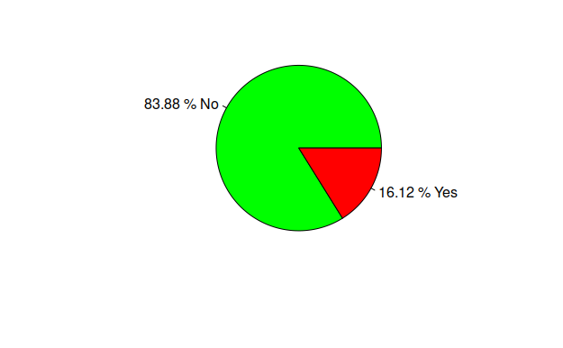

```r
attrition_split<-table(emp_df$Attrition)
pie(attrition_split/sum(attrition_split),labels = c(paste(round(attrition_split[1]*100/1470,2),"% No"),paste(round(attrition_split[2]*100/1470,2),"% Yes")),col=c("green","red"))
```

#### Department wise Attrition

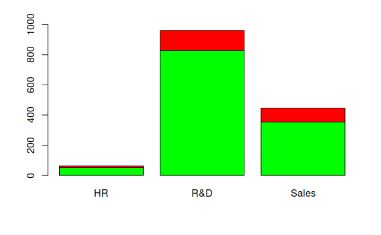

```r
dp_attrition<-table(select(emp_df,Attrition,Department))
barplot(dp_attrition,col=c("green","red"),names.arg = c("HR","R&D","Sales"),ylim =c(0,1000))
```

#### Attrition Rates in Department

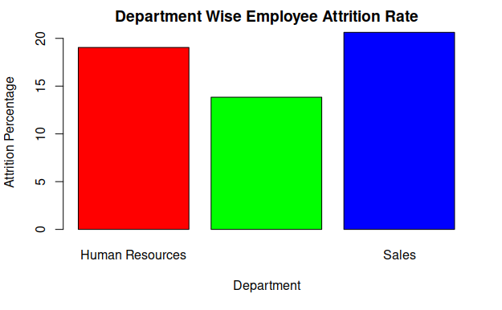

```r
barplot(dp_attrition[2,]*100/(dp_attrition[2,]+dp_attrition[1,]),col=rainbow(3),main="Department Wise Employee Attrition Rate",xlab="Department",ylab="Attrition Percentage")
```

#### Attrition Rates based on the Marital Status of the Employees.

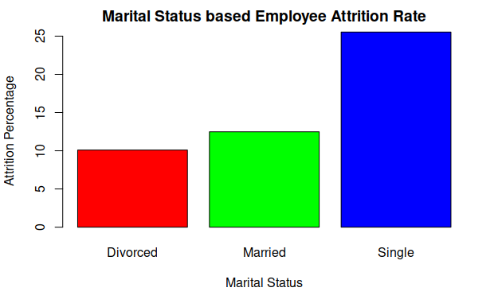

```r
ms_attrition<-table(select(emp_df,Attrition,MaritalStatus))
barplot(ms_attrition[2,]*100/(ms_attrition[2,]+ms_attrition[1,]),col=rainbow(3),main="Marital Status based Employee Attrition Rate",xlab="Marital Status",ylab="Attrition Percentage")
```

#### Exploring Attrition based on Age of Employees

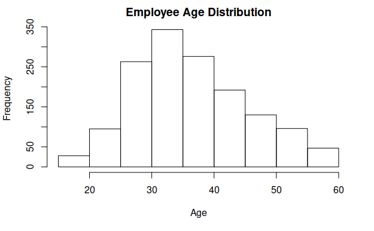

```r
hist(emp_df$Age,xlab="Age",main="Employee Age Distribution")
```

```r
skewness(emp_df$Age)
```

```
[1] 0.4128645
```

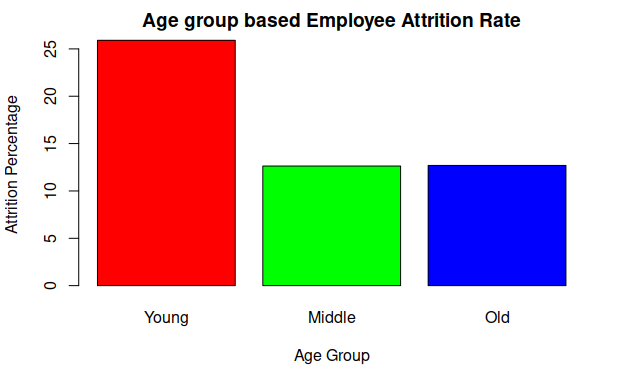

```r
age_dist<-factor(cut(emp_df$Age,breaks=c(18,30,48,60),include.lowest = TRUE),labels = c("Young","Middle","Old"))
age_attrition<-table(emp_df$Attrition,age_dist)
barplot(age_attrition[2,]*100/(age_attrition[2,]+age_attrition[1,]),col=rainbow(3),main="Age group based Employee Attrition Rate",xlab="Age Group",ylab="Attrition Percentage")
```

This doesn’t necessarily support that for a given position employee in the young age category has high chance of attrition.

#### Effect of Work Life Balance on Attrition

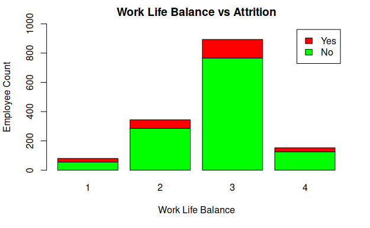

```r
wlb_attrition<-table(select(emp_df,Attrition,WorkLifeBalance))
barplot(wlb_attrition,col=c("green","red"),legend.text = c("No","Yes"),main="Work Life Balance vs Attrition",xlab="Work Life Balance",ylab="Employee Count",ylim=c(0,1000))
```

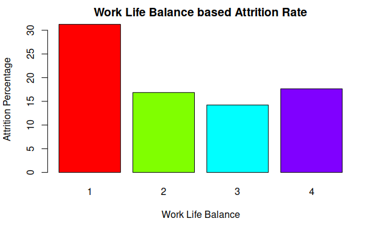

```r
barplot(wlb_attrition[2,]*100/(wlb_attrition[2,]+wlb_attrition[1,]),col=rainbow(4),main="Work Life Balance based Attrition Rate",xlab="Work Life Balance",ylab="Attrition Percentage")
```

#### Effect of Job Involvement on Attrition

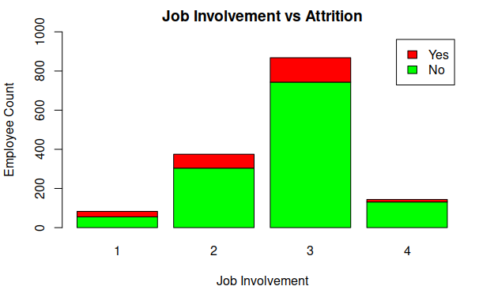

```r
ji_attrition<-table(select(emp_df,Attrition,JobInvolvement))
barplot(ji_attrition,col=c("green","red"),legend.text = c("No","Yes"),main="Job Involvement vs Attrition",xlab="Job Involvement",ylab="Employee Count",ylim=c(0,1000))
```

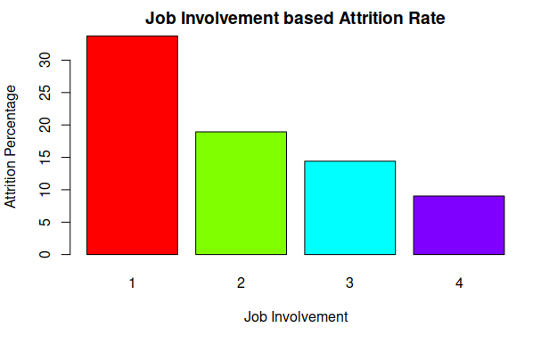

```r
barplot(ji_attrition[2,]*100/(ji_attrition[2,]+ji_attrition[1,]),col=rainbow(4),main="Job Involvement based Attrition Rate",xlab="Job Involvement",ylab="Attrition Percentage")
```

#### Effect of Distance from Home on Attrition.

The frequency distribution of Distance from home

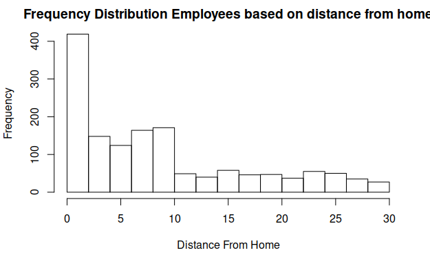

```r
hist(emp_df$DistanceFromHome,xlab="Distance From Home",main="Frequency Distribution Employees based on distance from home")
```

The Distance from Home variable is not following a normal distribution, because naturally people would want to avoid more travel time. We Categorize the employee based on the distance from home. 1. [0,5] - Near 2. [6,15] - Moderately Near 3. [16,30] - Far

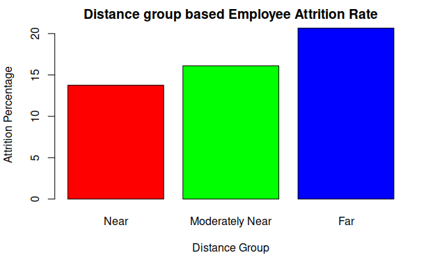

```r
dfh_dist<-factor(cut(emp_df$DistanceFromHome,breaks=c(0,5,15,30),include.lowest = TRUE),labels=c("Near","Moderately Near","Far"))
dfh_attrition<-table(emp_df$Attrition,dfh_dist)
barplot(dfh_attrition[2,]*100/(dfh_attrition[2,]+dfh_attrition[1,]),col=rainbow(3),main="Distance group based Employee Attrition Rate",xlab="Distance Group",ylab="Attrition Percentage")
```

#### Effect of Business Travel on Attrition

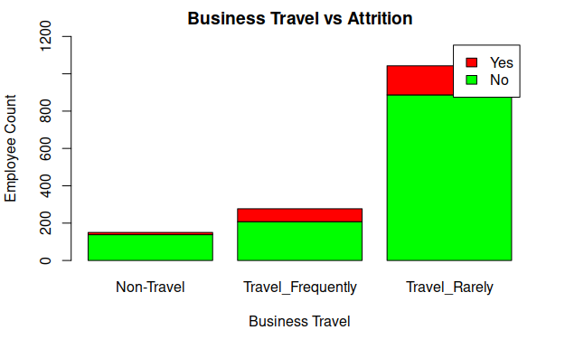

```r
bs_attrition<-table(select(emp_df,Attrition,BusinessTravel))
barplot(bs_attrition,col=c("green","red"),legend.text = c("No","Yes"),main="Business Travel vs Attrition",xlab="Business Travel",ylab="Employee Count",ylim=c(0,1200))
```

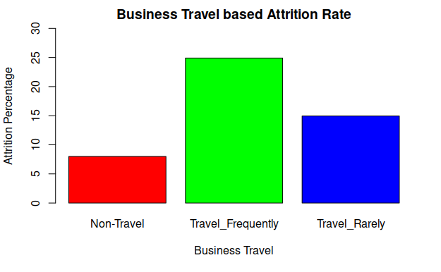

```r
barplot(bs_attrition[2,]*100/(bs_attrition[2,]+bs_attrition[1,]),col=rainbow(3),main="Business Travel based Attrition Rate",xlab="Business Travel",ylab="Attrition Percentage",ylim=c(0,30))
```

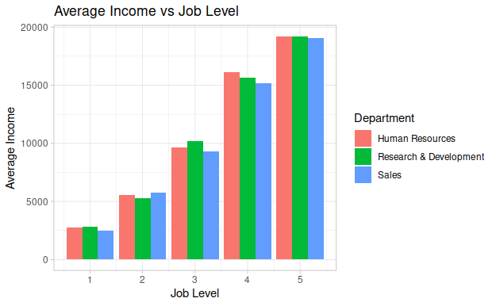

```r
library(ggplot2)
s<-data.frame(aggregate(emp_df$MonthlyIncome,by=list(Department=emp_df$Department,Job_level=emp_df$JobLevel),FUN=mean))
names(s)<-c("Department","Job_Level","Avg_Income")
ggplot(s,aes(fill=Department,x=Job_Level,y=Avg_Income))+geom_bar(position="dodge",stat = "identity")+theme_light()+xlab("Job Level")+ylab("Average Income")+ggtitle("Average Income vs Job Level")
```

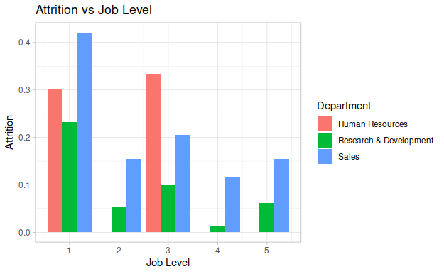

```r
s<-data.frame(aggregate(emp_df$Attrition,by=list(Department=emp_df$Department,Job_level=emp_df$JobLevel),FUN=mean))
names(s)<-c("Department","Job_Level","Attrition")
ggplot(s,aes(fill=Department,x=Job_Level,y=Attrition))+geom_bar(position="dodge",stat = "identity")+theme_light()+xlab("Job Level")+ylab("Attrition")+ggtitle("Attrition vs Job Level")
```

[output not shown]

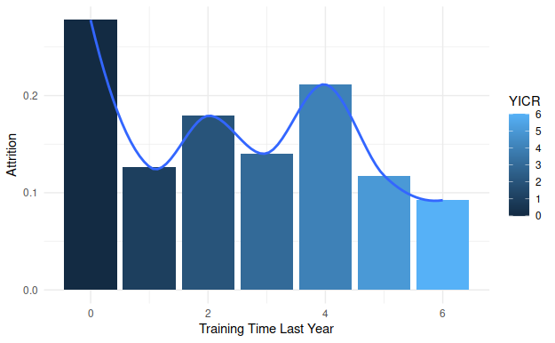

```r
s<-data.frame(aggregate(emp_df$Attrition,by=list(YICR=emp_df$TrainingTimesLastYear),FUN=mean))
names(s)<-c("YICR","Attrition")
ggplot(s,aes(x=YICR,y=Attrition))+geom_bar(stat = "identity",aes(fill=YICR))+theme_minimal()+xlab("Training Time Last Year")+stat_smooth(span=0.7)
```

### Statistical Analysis of variable.

For Age

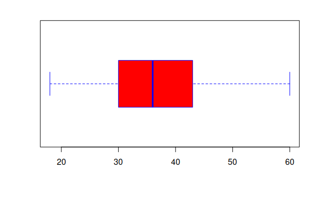

```r
boxplot(emp_df$Age,range=1.5,col=c("red"),border=c("blue"),horizontal = TRUE)
```

For Distance From Home

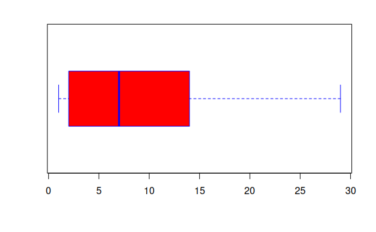

```r
boxplot(emp_df$DistanceFromHome,range=1.5,col=c("red"),border=c("blue"),horizontal = TRUE)
```

For HourlyRate

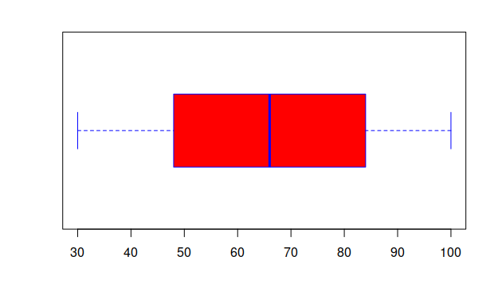

```r
boxplot(emp_df$HourlyRate,range=1.5,col=c("red"),border=c("blue"),horizontal = TRUE)
```

For Monthly Income

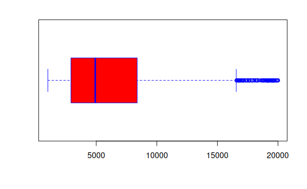

```r
boxplot(emp_df$MonthlyIncome,range=1.5,col=c("red"),border=c("blue"),horizontal = TRUE)
```

Monthly Income has lot a of outliers, need to either apply transformation or eliminate then. Applying Logrithmic Transformation on Monthly Income

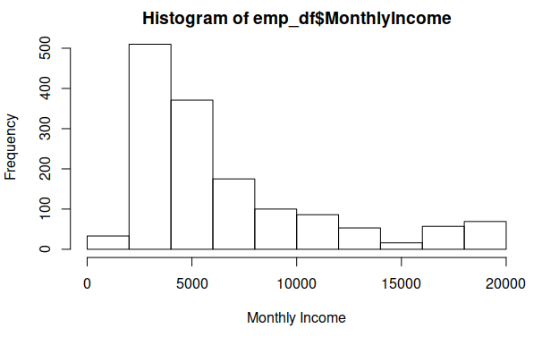

```r
hist(emp_df$MonthlyIncome,xlab="Monthly Income")
```

Histogram after logithmic transformation

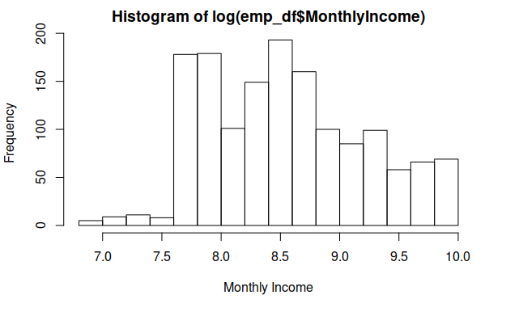

```r
hist(log(emp_df$MonthlyIncome),xlab="Monthly Income")
```

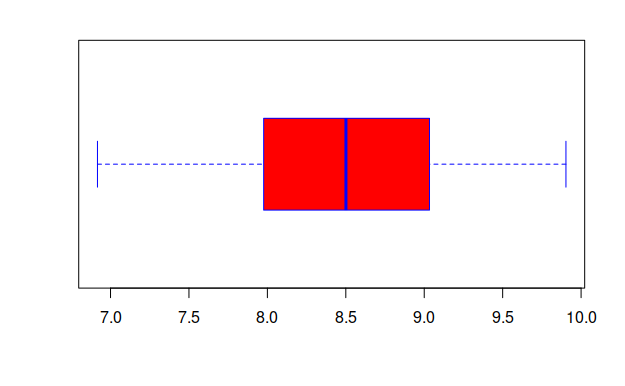

```r
emp_df$MonthlyIncome<-log(emp_df$MonthlyIncome)
boxplot(emp_df$MonthlyIncome,col=c("red"),border=c("blue"),range=1.5,horizontal = TRUE)
```

For Monthly Rate

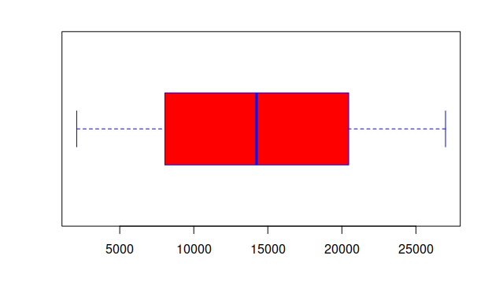

```r
boxplot(emp_df$MonthlyRate,range=1.5,col=c("red"),border=c("blue"),horizontal = TRUE)
```

For Number of Companies Worked

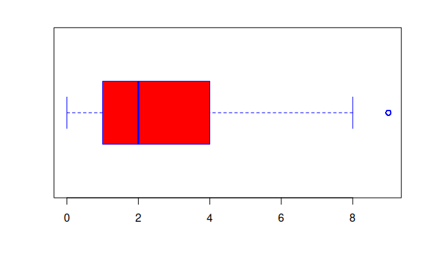

```r
boxplot(emp_df$NumCompaniesWorked,range=1.5,col=c("red"),border=c("blue"),horizontal = TRUE)
```

```r
boxplot.stats(emp_df$NumCompaniesWorked)
```

```
$stats
[1] 0 1 2 4 8

$n
[1] 1470

$conf
[1] 1.876371 2.123629

$out
 [1] 9 9 9 9 9 9 9 9 9 9 9 9 9 9 9 9 9 9 9 9 9 9 9 9 9 9 9 9 9 9 9 9 9 9 9
[36] 9 9 9 9 9 9 9 9 9 9 9 9 9 9 9 9 9
```